# Sentiment analysis: Climate-related speeches by danish prime ministers Anders Fogh and Mette Frederiksen

### NRC lexicon for sentiment analysis

With the NRC lexicon I can “bin” the words of the text by the feelings they’re typically associated with. As above, I use inner_join() to combine the frederiksen2 non-stopword text with the nrc lexicon:

```r
frederiksen2_nrc <- frederiksen2_stop %>%
  inner_join(get_sentiments("nrc"))
```

I then check which are excluded using `anti_join()`:

```r
frederiksen2_exclude <- frederiksen2_stop %>%
  anti_join(get_sentiments("nrc"))

View(frederiksen2_exclude)

# Counting words to find the most excluded:
frederiksen2_exclude_n <- frederiksen2_exclude %>%
  count(word, sort = TRUE)

head(frederiksen2_exclude_n)
```

```
## # A tibble: 6 × 2
##   word        n
##   <chr>   <int>
## 1 mette      13
## 2 climate    12
## 3 2021       10
## 4 23         10
## 5 april      10
## 6 den        10
```

Now I find some counts by sentiment and word, and then facet them:

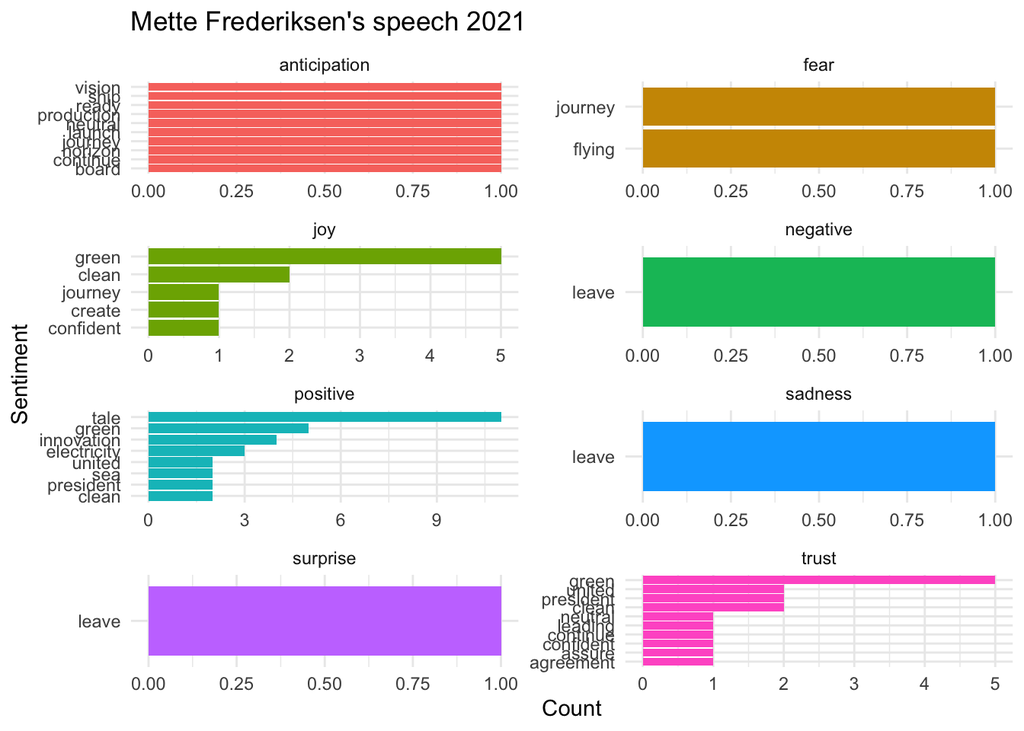

```r
frederiksen2_nrc_n5 <- frederiksen2_nrc %>%
  count(word,sentiment, sort = TRUE) %>%
  group_by(sentiment) %>%
  top_n(5) %>%
  ungroup()

frederiksen2_nrc_gg <- ggplot(data = frederiksen2_nrc_n5, aes(x = reorder(word,n), y = n, fill = sentiment)) +
  geom_col(show.legend = FALSE) +
  facet_wrap(~sentiment, ncol = 2, scales = "free") +
  coord_flip() +
  theme_minimal() +
  labs(title = "Mette Frederiksen's speech 2021",
       x = "Sentiment", y = "Count")

# Show it
frederiksen2_nrc_gg
```

```r
# Save it
ggsave(plot = frederiksen2_nrc_gg,
       here("figures","frederiksen2_nrc_sentiment.png"),
       height = 8,
       width = 5)
```

It seems that, as with the third speech, the word “green” shows up in NRC lexicon as “trust” and “joy”. I check this again:

```r
green <- get_sentiments(lexicon = "nrc") %>%
  filter(word == "green")

# Indeed, the word green belongs to the sentiments 'joy', 'positive' and 'trust' in the NRC lexicon:
green
```

```
## # A tibble: 3 × 2
##   word  sentiment
##   <chr> <chr>
## 1 green joy
## 2 green positive
## 3 green trust
```

Finally, I want to create a combined visual with the sentiments of all four speeches.

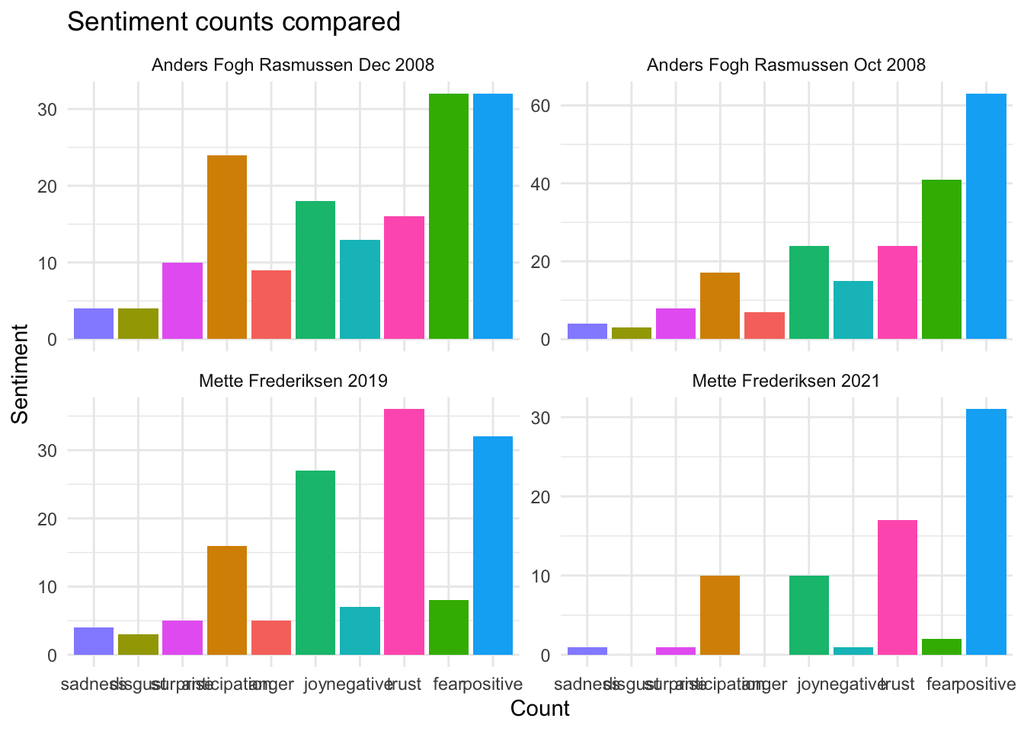

```r
# First, I add a document label to each of the earlier faceted speeches
fogh1_nrc_n5$document <- "Anders Fogh Rasmussen Oct 2008"
fogh2_nrc_n5$document <- "Anders Fogh Rasmussen Dec 2008"
frederiksen1_nrc_n5$document <- "Mette Frederiksen 2019"
frederiksen2_nrc_n5$document <- "Mette Frederiksen 2021"

# Then I combine the four into one data frame
all_sentiments_nrc <- bind_rows(
  fogh1_nrc_n5,
  fogh2_nrc_n5,
  frederiksen1_nrc_n5,
  frederiksen2_nrc_n5
)

# Create the plot
facet_sentiment_plot <- ggplot(all_sentiments_nrc, aes(y = reorder(sentiment, n), x = n, fill = sentiment)) +
  geom_col(show.legend = FALSE) +
  facet_wrap(~ document, scales = "free_y") +
  coord_flip() +
  theme_minimal() +
  labs(title = "Sentiment counts compared",
       x = "Sentiment", y = "Count")

# Save it
ggsave(plot = facet_sentiment_plot,
       here("figures","facet_sentiment_plot.png"),
       height = 8,
       width = 5)

# Show plot
facet_sentiment_plot
```